# Memoria caso práctico 2021: La pandemia COVID-19 en España y la influencia de la vacunación

Javier Garrote

9/12/2021

# Índice

1. Resumen
2. Introducción
   - Objetivo del caso práctico
   - Metodología de trabajo
   - Formato R Markdown
3. Estudio de los datos
   - España
   - Extremadura
   - Canarias
4. Conclusiones
5. Referencias

# Resumen

Los datos estudiados sobre la pandemia del virus COVID-19 en España evidencian una correlación entre el número de personas vacunadas y la evolución positiva de la pandemia, disminuyendo así el número de enfermos y hospitalizaciones. Asimismo, se observa como factores como las medidas políticas o el turismo influyen en la evolución de la pandemia, llegando incluso algunos de estos factores a que se frustre el progreso de la vacunación en un período determinado de tiempo este mismo año.

# Introducción

## Objetivo del caso práctico

Mostrar la influencia de la vacunación en la pandemia de la COVID-19, comparando los datos a partir del inicio de la vacunación con los datos de antes de la vacunación.

## Metodología de trabajo

Se tratan los datos sobre la pandemia del virus COVID-19 obtenidos desde la página del Ministerio de sanidad, el repositorio de Datadista en Github y los datos de mortalidad del INE para obtener gráficas sobre la evolución diaria de la pandemia y la vacunación en los siguientes territorios: España, Extremadura y Canarias (en este orden).

## Formato R markdown

Para convertir este documento de formato .rmd a .html ha sido necesario instalar un paquete en R llamado **knitr**. Este paquete tiene como objetivo generar informes a partir del código escrito en R implementando además la acción de otros paquetes en este proceso.

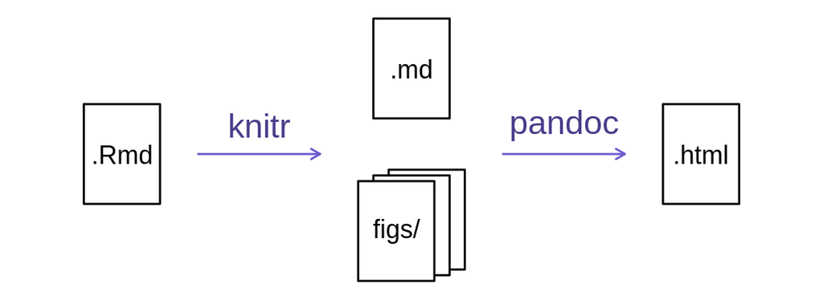

Knitr en este caso ha transformado el formato markdown a texto con formato estandarizado en html y el script de R en imágenes estáticas. Además, ha incluido el script de R que ha sido necesario para generar cada una de las gráficas encima de cada una de estas imágenes estáticas.

También he utilizado knitr para incluir imágenes externas al script de r, como la imagen del mono que hay más abajo.

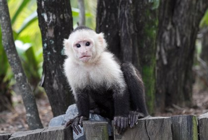

```r
knitr::include_graphics("img/mono.jpg")
```

Al principio del documento en R Markdown, he definido los comandos de knitr que irán asociados por defecto a cada fragmento de código en R.

```r
  knitr::opts_chunk$set(echo = TRUE, # El script de R ejecutado se imprimirá en el HTML a menos que se especifique lo contrario

                        out.width="100%", # El ancho de las imágenes estáticas y gráficas interactivas que se generan a partir de las gráficas será del 100% disponible a menos que se especifique otro valor

                        warning=FALSE, # Los avisos de la consola al ejecutar el código no se imprimirán en el HTML a menos que se especifique lo contrario

                        message=FALSE) # Los mensajes de la consola al ejecutar el código no se imprimirán en el HTML a menos que se especifique lo contrario
```

No obstante, hay que tener en cuenta que las gráficas interactivas no funcionarían si knitr utiliza el mismo procedimiento que con las gráficas generadas con ggplot() (e incluso no se exportaría la imagen estática de las mismas sin instalar paquetes adicionales).

Es por eso que para que no haya errores al exportar las gráficas interactivas es necesario instalar el paquete **htmlwidgets**. La función de htmlwidgets es la de exportar las gráficas interactivos de R junto con las librerías de Javascript necesarias para su correcta visualización. Este paquete interviene al visualizar la gráfica interactiva en las previsualizaciones de R, pero también interviene al exportar estas gráficas a HTML o a una aplicación de Shiny.

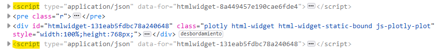

En la imagen anterior, se puede observar como al importar desde .rmd a .html se ha añadido código en Javascript a cada gráfica.

# Estudio de los datos

## Estudio de la pandemia en España

Para importar los datos necesarios para hacer las gráficas, vamos a necesitar el paquete **readr**. En este caso cargamos directamente la librería **tidyverse**, la cual incluye diversos paquetes que vamos a necesitar más adelante.

```r
library(tidyverse)
```

Los paquetes que se cargan al ejecutar este comando son: ggplot2, purrr, tibble, dplyr, tidyr, stringr, readr y forcats. Una breve explicación de para qué sirve cada uno.

- **ggplot2**: crea elegantes gráficas a partir de los datos especificados y permite su modificación y personalización al añadir capas.
- **purr**: proporciona herramientas para trabajar con funciones y vectores.
- **tibble**: modificación del dataframe que gracias a sus restricciones obligan a enfrentarse con los problemas en el código antes de se acumulen los errores. Además contiene una modificación de la función *print()* que es más adecuada para grandes cantidades de datos y objetos complejos.
- **dplyr**: proporciona comandos para manipular datos enfrentándose a desafíos comunes.
- **tidyr**: ayuda a tener datos *tidy*, lo que facilitará trabajar con ellos cuando sean manipulados por otras herramientas del *tidyverse*.
- **stringr**: nos ayuda a manejar los datos que están en *strings* utilizando comandos que pueden modificarlos al encontrar patrones en estas series de datos.
- **readr**: puede importar datos en formato rectangular (como csv) de manera rápida y ordenada.
- **forcats**: trabaja con *factors*, un tipo de datos que se basa en las variables categóricas con un número determinado de valores fijos y conocidos.

### 1. Evolución diaria de la pandemia en España

Primero importamos los datos desde la URL del Ministerio de Sanidad.

```r
casos_diag_ccaa <- read_csv("https://cnecovid.isciii.es/covid19/resources/casos_diag_ccaadecl.csv")
casos_hosp_uci <- read_csv("https://cnecovid.isciii.es/covid19/resources/casos_hosp_uci_def_sexo_edad_provres.csv")
```

Para la gráfica de evolución diaria de nuevos casos de enfermos trabajaremos con el dataframe *casos_diag_ccaa*. Este dataframe recoge datos por cada comunidad autónoma, por eso agruparemos y sumamos por fecha para obtener el número total de nuevos casos en España.

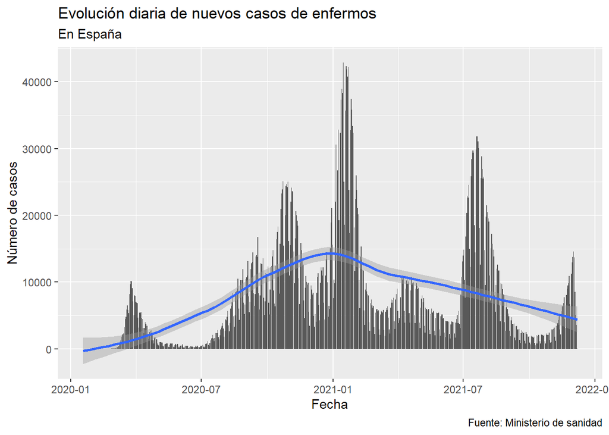

```r
esp_casos_diag_ccaa <- casos_diag_ccaa %>% group_by(fecha) %>% summarize(num_casos = sum(num_casos), num_casos_prueba_pcr = sum(num_casos_prueba_pcr), num_casos_prueba_test_ac = sum(num_casos_prueba_test_ac), num_casos_prueba_ag = sum(num_casos_prueba_ag)) #Agrupamos por fecha y sumamos las columnas agrupadas

# Utilizamos las variables $fecha (fecha en la que se registra la información) y $num_casos (número de casos nuevos) del dataframe esp_casos_diag_ccaa que contiene solamente los datos diarios correspondientes a España.

ggplot(esp_casos_diag_ccaa, aes(x = fecha, y = num_casos)) + geom_col() + labs(title = "Evolución diaria de nuevos casos de enfermos",
              subtitle = "En España",
              caption = "Fuente: Ministerio de sanidad",
              x = "Fecha", y = "Número de casos") + geom_smooth()
```

**Observaciones sobre la gráfica:** Al observar la línea de tendencia vemos que el mayor pico de coronavirus fue sobre el principio del año 2021, y que en general el número de enfermos se ha ido reduciendo.

En este mismo data frame, disponemos de los datos correspondientes al método para diagnosticar la enfermedad. En la siguiente gráfica se representa el número de casos según su forma de diagnóstico. He escogido las tres formas de diagnóstico más conocidas: prueba PCR, test de anticuerpos y prueba de detección de antígeno.

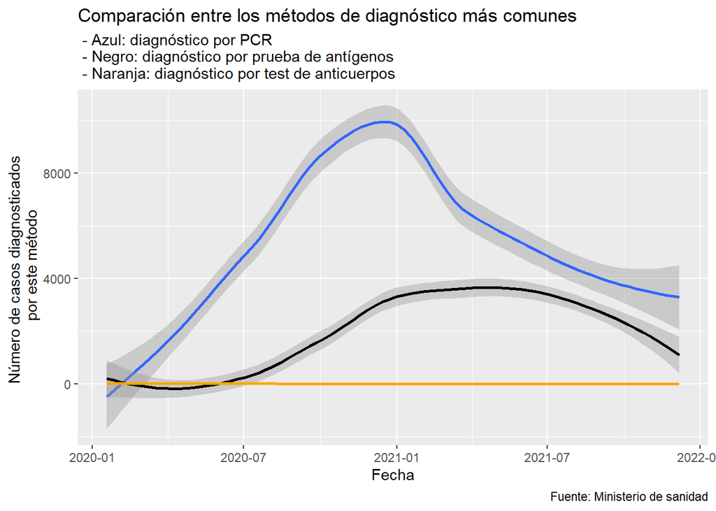

```r
# Utilizamos el mismo dataframe. Tres variables son de nueva introducción: $num_casos_prueba_pcr (número de casos con prueba de laboratorio PCR o técnicas moleculares), $num_casos_prueba_ag (número de casos con prueba de laboratorio de test de detección de antígeno) y $num_casos_prueba_test_ac (Número de casos con prueba de laboratorio de test rápido de anticuerpos).

ggplot(esp_casos_diag_ccaa, aes(x = fecha, y  = num_casos_prueba_pcr)) + geom_smooth() + geom_smooth(aes(y = num_casos_prueba_ag), color = "black") + geom_smooth(aes(y = num_casos_prueba_test_ac), color = "orange")  + labs(title = "Comparación entre los métodos de diagnóstico más comunes",
              subtitle = " - Azul: diagnóstico por PCR \n - Negro: diagnóstico por prueba de antígenos \n - Naranja: diagnóstico por test de anticuerpos",
              caption = "Fuente: Ministerio de sanidad",
              x = "Fecha", y = "Número de casos diagnosticados \n por este método")
```

**Observaciones sobre la gráfica:** Al observar el número de casos que se ha diagnosticado en España por cada técnica, se observa como las pruebas PCR han sido la principal forma de diagnosticar a los enfermos. Los test de anticuerpos, pese a ser bastante mencionados en las noticias, no han sido una herramienta de diagnóstico muy utilizada.

Para la gráfica de evolución diaria de número de fallecidos (y las siguientes) trabajaremos con el dataframe *casos_hosp_uci*. Este dataframe recoge datos por cada provincia, por eso agruparemos y sumamos por fecha para obtener el número total de nuevos casos en España.

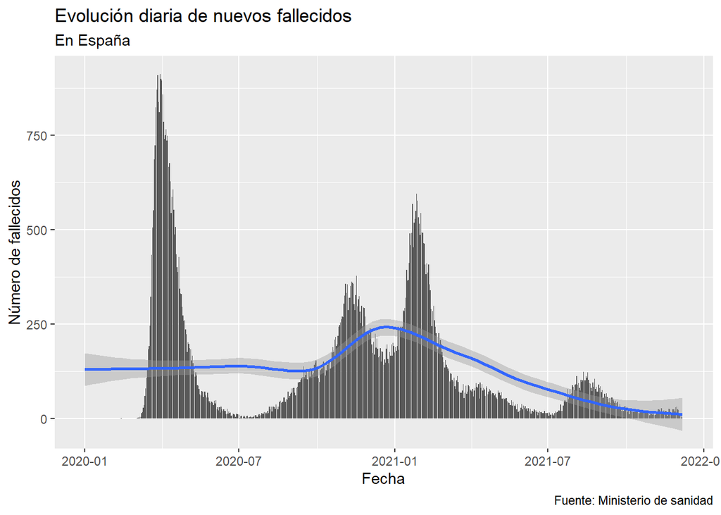

```r
esp_casos_hosp_uci <- casos_hosp_uci %>% group_by(fecha) %>% summarize(num_casos = sum(num_casos), num_hosp = sum(num_hosp), num_uci = sum(num_uci), num_def = sum(num_def))

#Utilizamos las variables $fecha (fecha en la que se registra la información) y $num_def (número de defunciones por COVID-19) del dataframe esp_casos_hosp_uci que contiene solamente los datos diarios correspondientes a España.

ggplot(esp_casos_hosp_uci, aes(x = fecha, y = num_def)) + geom_col() + labs(title = "Evolución diaria de nuevos fallecidos",
              subtitle = "En España",
              caption = "Fuente: Ministerio de sanidad",
              x = "Fecha", y = "Número de fallecidos") + geom_smooth()
```

**Observaciones sobre la gráfica:** Al observar la línea de tendencia vemos que el mayor pico de fallecidos fue sobre el principio del año 2021, y que en general el número de fallecidos se ha ido reduciendo. Coincide en ese sentido con la tendencia del número de enfermos.

Gráfica de evolución diaria de número de hospitalizados con el dataframe anterior:

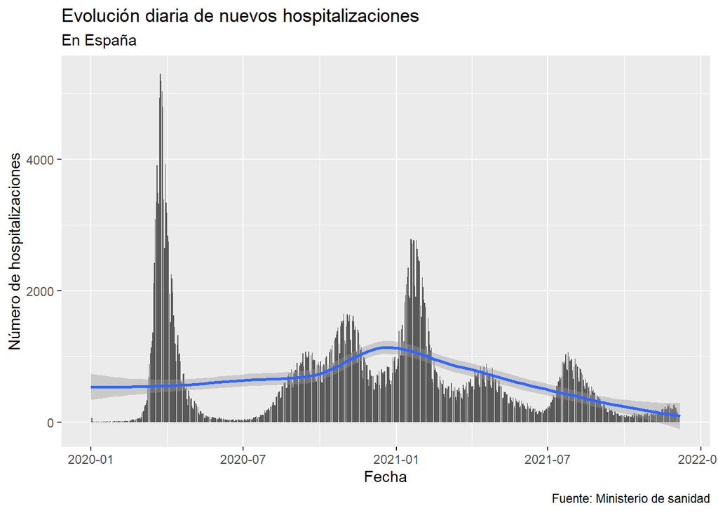

```r
#Utilizamos el dataframe anterior. Introducimos una nueva variable: $num_hosp (número de hospitalizados por COVID-19 diarios)

ggplot(esp_casos_hosp_uci, aes(x = fecha, y = num_hosp)) + geom_col() + labs(title = "Evolución diaria de nuevos hospitalizaciones",
              subtitle = "En España",
              caption = "Fuente: Ministerio de sanidad",
              x = "Fecha", y = "Número de hospitalizaciones") + geom_smooth()
```

**Observaciones sobre la gráfica:** Coincide de nuevo con las observaciones de las gráfica anterior.

Gráfica de evolución diaria de número de enfermos en UCI netos con el dataframe anterior:

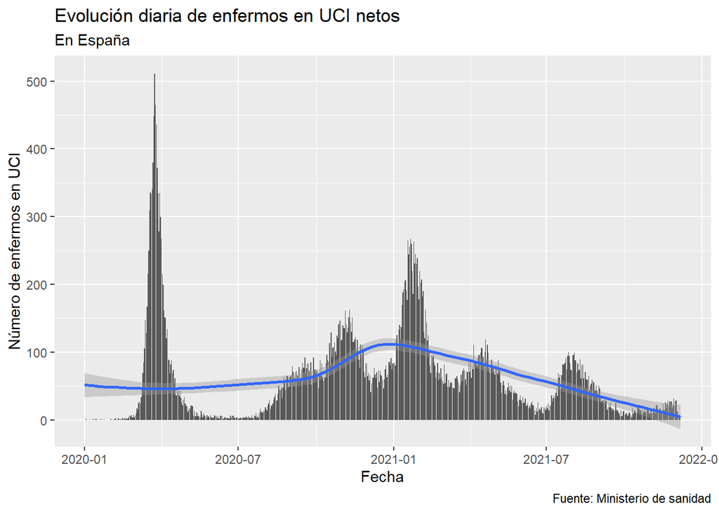

```r
#Utilizamos el dataframe anterior. Introducimos una nueva variable: $num_uci (número de enfermos en UCI por COVID-19 diarios)

ggplot(esp_casos_hosp_uci, aes(x = fecha, y = num_uci)) + geom_col() + labs(title = "Evolución diaria de enfermos en UCI netos",
              subtitle = "En España",
              caption = "Fuente: Ministerio de sanidad",
              x = "Fecha", y = "Número de enfermos en UCI") + geom_smooth()
```

**Observaciones sobre la gráfica:** Coincide de nuevo con las observaciones de las gráfica anterior.

A continuación voy a volver a representar las mismas gráficas pero por cada 100 000 habitantes.

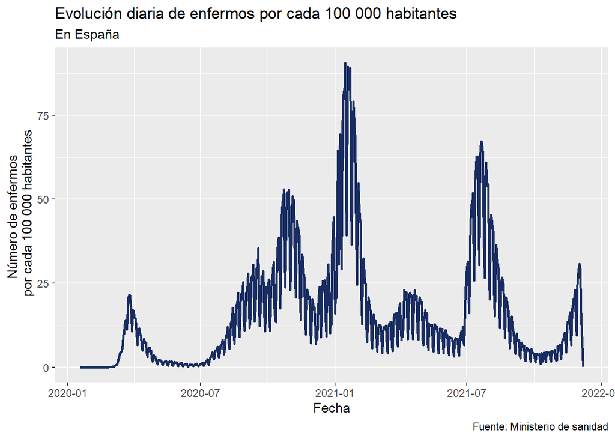

```r
esp_casos_diag_ccaa$censo_esp <- c(47394223) #Introducimos en una variable el censo de España
esp_casos_diag_ccaa$ev100k_num_casos <- (esp_casos_diag_ccaa$num_casos * 100000) / esp_casos_diag_ccaa$censo_esp #Calculamos el número de casos por 100 000 habitantes


ggplot(esp_casos_diag_ccaa, aes(x = fecha, y = ev100k_num_casos)) + geom_line(size = 1, color = "#182C61") + labs(title = "Evolución diaria de enfermos por cada 100 000 habitantes",
              subtitle = "En España",
              caption = "Fuente: Ministerio de sanidad",
              x = "Fecha", y = "Número de enfermos \n por cada 100 000 habitantes")
```

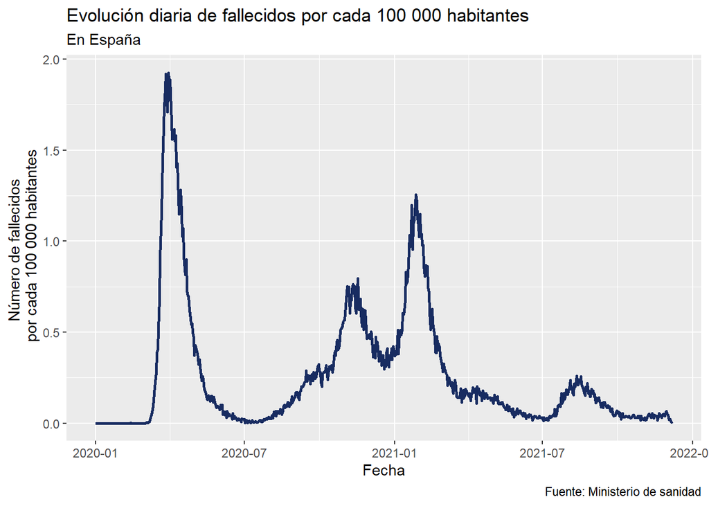

```r
esp_casos_hosp_uci$censo_esp <- c(47394223) #Introducimos en una variable el censo de España
esp_casos_hosp_uci$ev100k_num_def <- (esp_casos_hosp_uci$num_def * 100000) / esp_casos_hosp_uci$censo_esp #Calculamos el número de fallecidos por 100 000 habitantes


ggplot(esp_casos_hosp_uci, aes(x = fecha, y = ev100k_num_def)) + geom_line(size = 1, color = "#182C61") + labs(title = "Evolución diaria de fallecidos por cada 100 000 habitantes",
              subtitle = "En España",
              caption = "Fuente: Ministerio de sanidad",
              x = "Fecha", y = "Número de fallecidos \n por cada 100 000 habitantes")
```

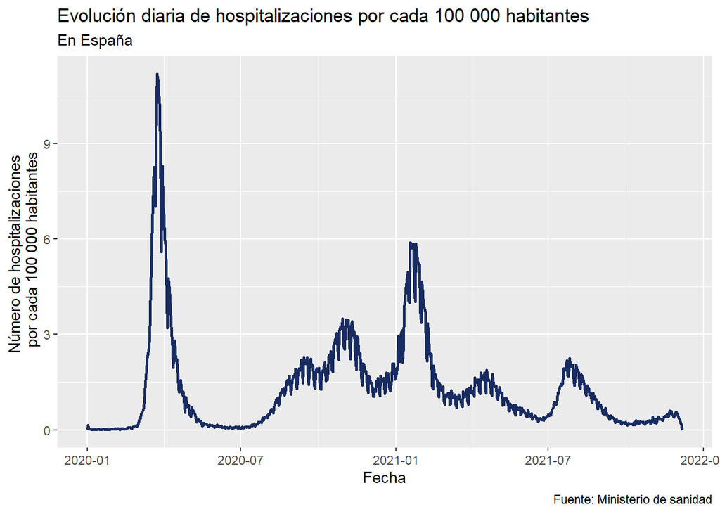

```r
esp_casos_hosp_uci$ev100k_num_hosp <- (esp_casos_hosp_uci$num_hosp * 100000) / esp_casos_hosp_uci$censo_esp #Calculamos el número de hospitalizados por 100 000 habitantes


ggplot(esp_casos_hosp_uci, aes(x = fecha, y = ev100k_num_hosp)) + geom_line(size = 1, color = "#182C61") + labs(title = "Evolución diaria de hospitalizaciones por cada 100 000 habitantes",
              subtitle = "En España",
              caption = "Fuente: Ministerio de sanidad",
              x = "Fecha", y = "Número de hospitalizaciones \n por cada 100 000 habitantes")
```

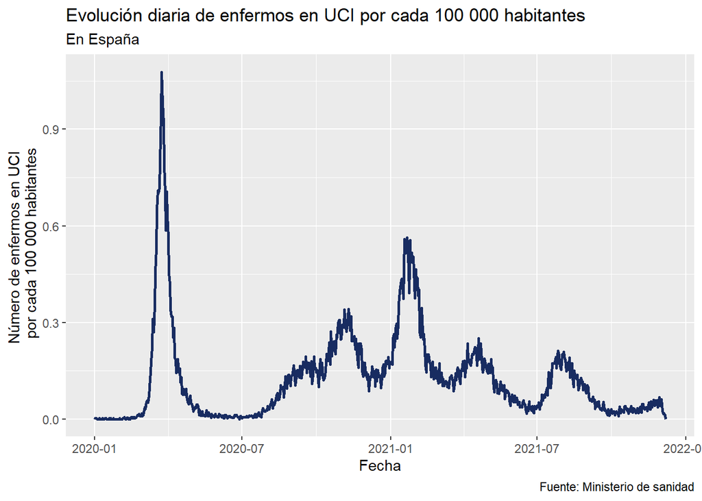

```r
esp_casos_hosp_uci$ev100k_num_uci <- (esp_casos_hosp_uci$num_uci * 100000) / esp_casos_hosp_uci$censo_esp #Calculamos el número de hospitalizados por 100 000 habitantes


ggplot(esp_casos_hosp_uci, aes(x = fecha, y = ev100k_num_uci)) + geom_line() + geom_line(size = 1, color = "#182C61") + labs(title = "Evolución diaria de enfermos en UCI por cada 100 000 habitantes",
              subtitle = "En España",
              caption = "Fuente: Ministerio de sanidad",
              x = "Fecha", y = "Número de enfermos en UCI \n por cada 100 000 habitantes")
```

Para hacer las mismas gráficas (pero esta vez de evolución acumulada) trabajaremos con los mismos data frame y con la misma sintaxis para las gráficas, solo que crearemos nuevas columnas con la suma acumulatoria utilizando la función *cumsum()*.

```r
#Creamos una columna de acumulados para cada variable
esp_casos_diag_ccaa$acum_num_casos <- cumsum(esp_casos_diag_ccaa$num_casos)
esp_casos_hosp_uci$acum_num_hosp <- cumsum(esp_casos_hosp_uci$num_hosp)
esp_casos_hosp_uci$acum_num_uci <- cumsum(esp_casos_hosp_uci$num_uci)
esp_casos_hosp_uci$acum_num_def <- cumsum(esp_casos_hosp_uci$num_def)
```

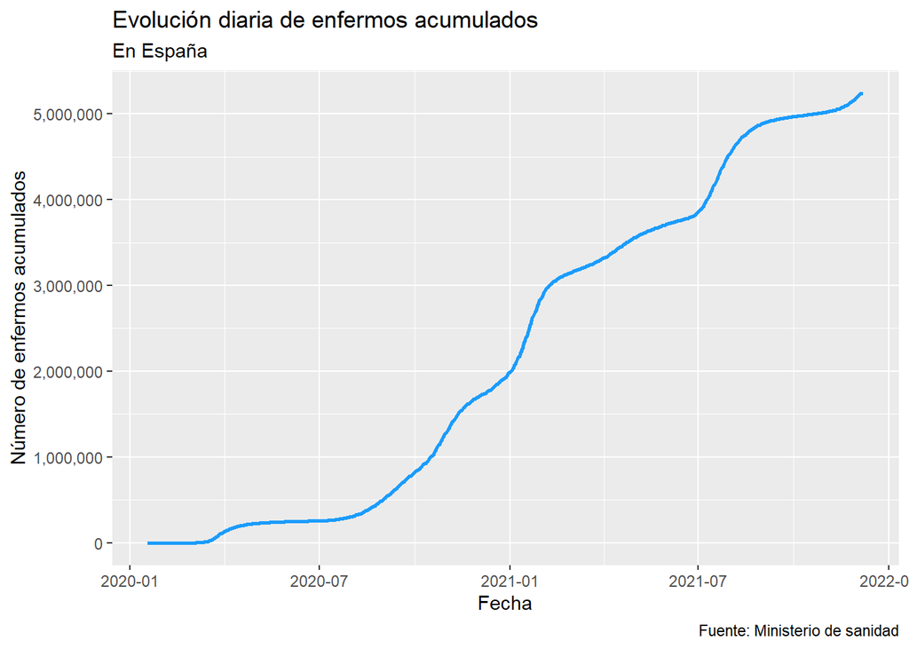

```r
ggplot(esp_casos_diag_ccaa, aes(x = fecha, y = acum_num_casos)) + geom_line(size = 1, color = "#1B9CFC") + labs(title = "Evolución diaria de enfermos acumulados",
              subtitle = "En España",
              caption = "Fuente: Ministerio de sanidad",
              x = "Fecha", y = "Número de enfermos acumulados") + scale_y_continuous(labels = scales::comma)
```

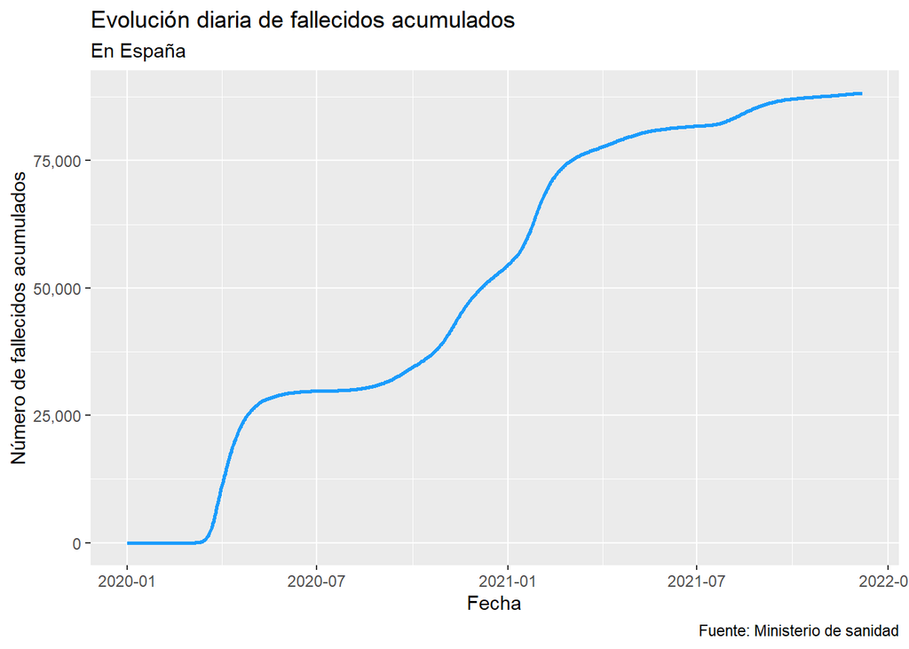

```r
ggplot(esp_casos_hosp_uci, aes(x = fecha, y = acum_num_def)) + geom_line(size = 1, color = "#1B9CFC") + labs(title = "Evolución diaria de fallecidos acumulados",
              subtitle = "En España",
              caption = "Fuente: Ministerio de sanidad",
              x = "Fecha", y = "Número de fallecidos acumulados") + scale_y_continuous(labels = scales::comma)
```

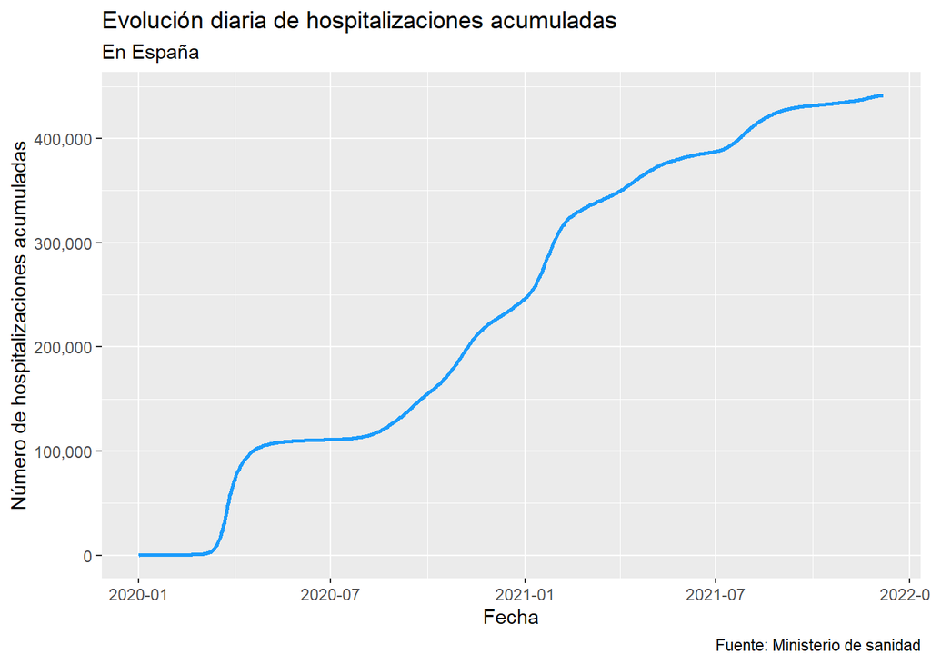

```r
ggplot(esp_casos_hosp_uci, aes(x = fecha, y = acum_num_hosp)) + geom_line(size = 1, color = "#1B9CFC") + labs(title = "Evolución diaria de hospitalizaciones acumuladas",
              subtitle = "En España",
              caption = "Fuente: Ministerio de sanidad",
              x = "Fecha", y = "Número de hospitalizaciones acumuladas") + scale_y_continuous(labels = scales::comma)
```

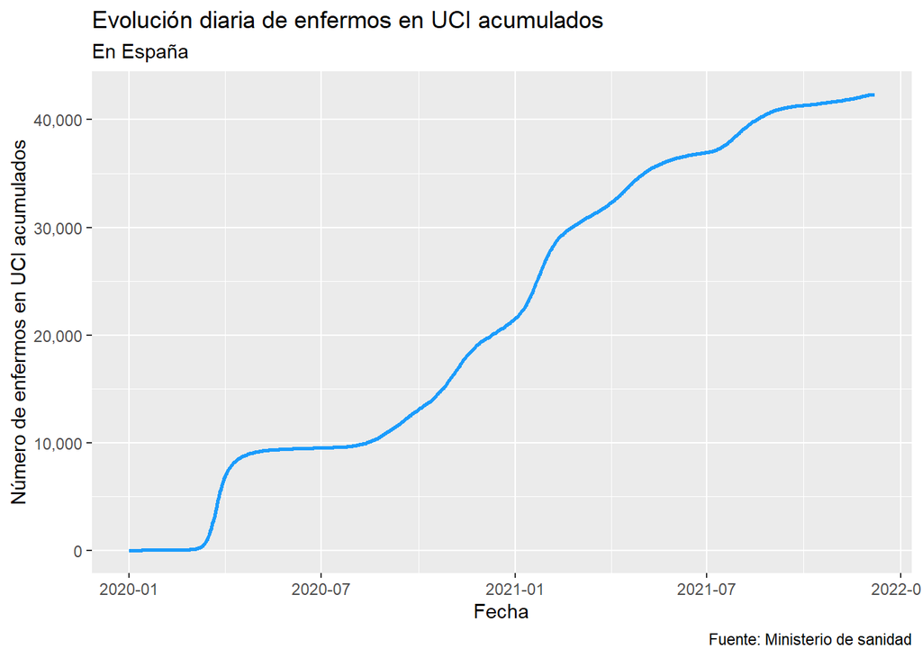

```r
ggplot(esp_casos_hosp_uci, aes(x = fecha, y = acum_num_uci)) + geom_line(size = 1, color = "#1B9CFC") + labs(title = "Evolución diaria de enfermos en UCI acumulados",
              subtitle = "En España",
              caption = "Fuente: Ministerio de sanidad",
              x = "Fecha", y = "Número de enfermos en UCI acumulados") + scale_y_continuous(labels = scales::comma)
```

### 2. Incidencia acumulada de la pandemia en España

Para calcular la incidencia acumulada vamos a reutilizar los datos de la evolución acumulada diaria del número de casos. Por lo tanto el dataframe a utilizar es *esp_casos_diag_ccaa* y las variables serán *fecha* y el resultado de la función que he creado más abajo *iacumuladaesp*.

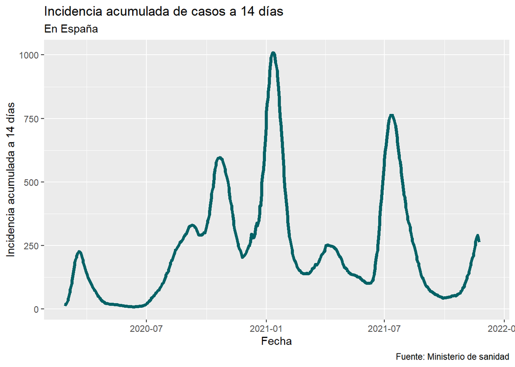

```r
# En la función, t es el número de días transcurridos desde el primer día existente en el dataframe sin filtrar y n el número de días para el que hacer la incidencia acumulada.
iacumuladaesp <- function(t, n) {(((esp_incidencia_acumulada_a$acum_num_casos[t]-esp_incidencia_acumulada_a$acum_num_casos[esp_incidencia_acumulada_a$num_fila - n])/esp_incidencia_acumulada_a$censo_esp)*100000)}

esp_incidencia_acumulada_a <- esp_casos_diag_ccaa
esp_incidencia_acumulada_a <- filter(esp_incidencia_acumulada_a, num_casos > 15)
esp_incidencia_acumulada_a <- esp_incidencia_acumulada_a %>% mutate(num_fila = c(15:(n()+14))) #Creamos una columna que contenga números enteros ordenados desde n hasta llenar la última fila del dataframe

# Suelo utilizar el operador $ para redefinir variables pero en este caso no me queda otra opción que utilizar mutate() de dplyr porque la función n() para introducir los números de fila solamente funciona en las funciones de dplyr.

esp_incidencia_acumulada_a$incidencia_acumulada <- iacumuladaesp(esp_incidencia_acumulada_a$num_fila, 14)

ggplot(esp_incidencia_acumulada_a, aes(x = fecha, y = incidencia_acumulada)) + geom_line(size = 1.5, color = "#006266") + labs(title = "Incidencia acumulada de casos a 14 días",
              subtitle = "En España",
              caption = "Fuente: Ministerio de sanidad",
              x = "Fecha", y = "Incidencia acumulada a 14 días")
```

**Observaciones sobre la gráfica:** La incidencia acumulada es un término epidemiológico que refleja la expansión de una enfermedad en una población y en un tiempo determinado. Este dato es determinante a la hora de tomar decisiones políticas. <sup>1</sup>

Reutilizamos la función *iacumuladaesp* para calcular la incidencia acumulada a 10 y 7 días.

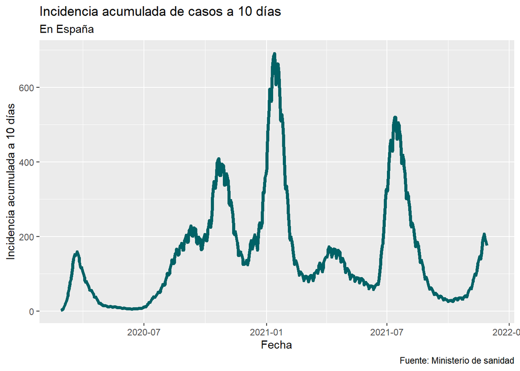

```r
#Redefinimos la función cambiando el dataframe del que cogemos los datos
iacumuladaesp <- function(t, n) {(((esp_incidencia_acumulada_b$acum_num_casos[t]-esp_incidencia_acumulada_b$acum_num_casos[esp_incidencia_acumulada_b$num_fila - n])/esp_incidencia_acumulada_b$censo_esp)*100000)}

esp_incidencia_acumulada_b <- esp_casos_diag_ccaa
esp_incidencia_acumulada_b <- filter(esp_incidencia_acumulada_b, num_casos > 10) #Esta vez filtramos para los valores mayores a 10
esp_incidencia_acumulada_b <- esp_incidencia_acumulada_b %>% mutate(num_fila = c(10:(n()+9))) #Creamos una columna que contenga números enteros ordenados desde n hasta llenar la última fila del dataframe
esp_incidencia_acumulada_b$incidencia_acumulada <- iacumuladaesp(esp_incidencia_acumulada_b$num_fila, 10)

ggplot(esp_incidencia_acumulada_b, aes(x = fecha, y = incidencia_acumulada)) + geom_line(size = 1.5, color = "#006266") + labs(title = "Incidencia acumulada de casos a 10 días",
              subtitle = "En España",
              caption = "Fuente: Ministerio de sanidad",
              x = "Fecha", y = "Incidencia acumulada a 10 días")
```

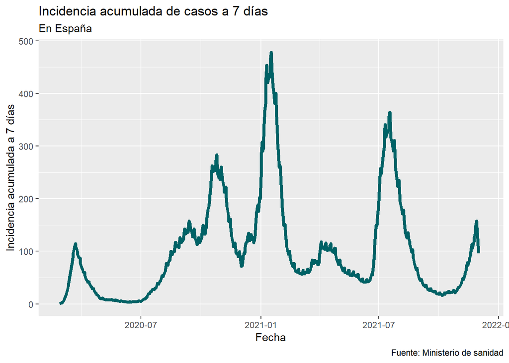

```r
#Redefinimos la función cambiando el dataframe del que cogemos los datos
iacumuladaesp <- function(t, n) {(((esp_incidencia_acumulada_c$acum_num_casos[t]-esp_incidencia_acumulada_c$acum_num_casos[esp_incidencia_acumulada_c$num_fila - n])/esp_incidencia_acumulada_c$censo_esp)*100000)}

esp_incidencia_acumulada_c <- esp_casos_diag_ccaa
esp_incidencia_acumulada_c <- filter(esp_incidencia_acumulada_c, num_casos > 7) #Esta vez filtramos para los valores mayores a 7
esp_incidencia_acumulada_c <- esp_incidencia_acumulada_c %>% mutate(num_fila = c(7:(n()+6))) #Creamos una columna que contenga números enteros ordenados desde n hasta llenar la última fila del dataframe
esp_incidencia_acumulada_c$incidencia_acumulada <- iacumuladaesp(esp_incidencia_acumulada_c$num_fila, 7)

ggplot(esp_incidencia_acumulada_c, aes(x = fecha, y = incidencia_acumulada))  + geom_line(size = 1.5, color = "#006266") + labs(title = "Incidencia acumulada de casos a 7 días",
              subtitle = "En España",
              caption = "Fuente: Ministerio de sanidad",
              x = "Fecha", y = "Incidencia acumulada a 7 días")
```

### 3. Datos de vacunación en España

Primero importamos los datos desde la URL del repositorio de Datadista en GitHub. En este caso voy a utilizar un método distinto para importar los datos. Primero descargaré el archivo en el directorio de trabajo definido en r, buscaré la ruta local del archivo y utilizaré la función nativa de R *read.table*.

```r
download.file(
  url = "https://raw.githubusercontent.com/datadista/datasets/master/COVID%2019/ccaa_vacunas.csv",
  destfile = "datosVacunacionGit.csv", method = "curl", quiet = TRUE)

rutaVacunaGit <- paste(getwd(), "/datosVacunacionGit.csv", sep = "") # Obtener la ruta del archivo dentro del directorio de trabajo


datosVacunacionGit <- read.table(rutaVacunaGit,  skip = 0, header = TRUE, sep = ",")
```

Al importar los datos nos encontramos con un problema, y es que hay que limpiarlos antes de poder hacer cualquier gráfica con ellos. Vamos a utilizar la librería **stringr**, que ya está cargada con **tidyverse**.

```r
# Primer paso: corregir los nombres de las variables

names(datosVacunacionGit) <- c("fecha_publicacion", "cod_ine", "ccaa", "dosis_entregadas_pfizer", "dosis_entregadas_moderna", "dosis_entregadas_astrazeneca", "dosis_entregadas_janssen", "dosis_entregadas_totales", "dosis_administradas", "porcentaje_de_dosis_administradas_por_100_habitantes", "porcentaje_sobre_entregadas", "personas_con_al_menos_una_dosis", "personas_con_pauta_completa", "porcentaje_con_pauta_completa", "fecha_de_la_ultima_vacuna_registrada")

# Segundo paso: eliminar los puntos para marcar los miles, ya que al pasar más adelante a formato número estos puntos se tratarán como comas decimales


datosVacunacionGit$dosis_entregadas_pfizer <- str_remove_all(datosVacunacionGit$dosis_entregadas_pfizer, "[.]")
datosVacunacionGit$dosis_entregadas_moderna <- str_remove_all(datosVacunacionGit$dosis_entregadas_moderna, "[.]")
datosVacunacionGit$dosis_entregadas_janssen <- str_remove_all(datosVacunacionGit$dosis_entregadas_janssen, "[.]")
datosVacunacionGit$dosis_entregadas_astrazeneca <- str_remove_all(datosVacunacionGit$dosis_entregadas_astrazeneca, "[.]")
datosVacunacionGit$dosis_entregadas_totales <- str_remove_all(datosVacunacionGit$dosis_entregadas_totales, "[.]")
datosVacunacionGit$dosis_administradas <- str_remove_all(datosVacunacionGit$dosis_administradas, "[.]")
datosVacunacionGit$personas_con_al_menos_una_dosis <- str_remove_all(datosVacunacionGit$personas_con_al_menos_una_dosis, "[.]")
datosVacunacionGit$personas_con_pauta_completa <- str_remove_all(datosVacunacionGit$personas_con_pauta_completa, "[.]")

#Tercer paso: cambiar las comas "," por puntos "." donde hace falta para que posteriormente sean reconocidos como comas decimales

datosVacunacionGit$porcentaje_de_dosis_administradas_por_100_habitantes <- str_replace_all(datosVacunacionGit$porcentaje_de_dosis_administradas_por_100_habitantes, "," , ".")
datosVacunacionGit$porcentaje_sobre_entregadas <- str_replace_all(datosVacunacionGit$porcentaje_sobre_entregadas, "," , ".")
datosVacunacionGit$porcentaje_con_pauta_completa <- str_replace_all(datosVacunacionGit$porcentaje_con_pauta_completa, "," , ".")

# Cuarto paso: pasar a formato numérico las variables que deberían ser numéricas

datosVacunacionGit$dosis_entregadas_pfizer <- as.numeric(datosVacunacionGit$dosis_entregadas_pfizer)
datosVacunacionGit$dosis_entregadas_moderna <- as.numeric(datosVacunacionGit$dosis_entregadas_moderna)
datosVacunacionGit$dosis_entregadas_janssen <- as.numeric(datosVacunacionGit$dosis_entregadas_janssen)
datosVacunacionGit$dosis_entregadas_astrazeneca <- as.numeric(datosVacunacionGit$dosis_entregadas_astrazeneca)
datosVacunacionGit$dosis_entregadas_totales <- as.numeric(datosVacunacionGit$dosis_entregadas_totales)
datosVacunacionGit$dosis_administradas <- as.numeric(datosVacunacionGit$dosis_administradas)
datosVacunacionGit$porcentaje_de_dosis_administradas_por_100_habitantes <- as.numeric(datosVacunacionGit$porcentaje_de_dosis_administradas_por_100_habitantes)
datosVacunacionGit$porcentaje_sobre_entregadas <- as.numeric(datosVacunacionGit$porcentaje_sobre_entregadas)
datosVacunacionGit$personas_con_al_menos_una_dosis <- as.numeric(datosVacunacionGit$personas_con_al_menos_una_dosis)
datosVacunacionGit$personas_con_pauta_completa <- as.numeric(datosVacunacionGit$personas_con_pauta_completa)
datosVacunacionGit$porcentaje_con_pauta_completa <- as.numeric(datosVacunacionGit$porcentaje_con_pauta_completa)

# Quinto paso: pasar a formato fecha las variables que dependan del tiempo

datosVacunacionGit$fecha_publicacion <- as.Date(datosVacunacionGit$fecha_publicacion)


# Sexto paso: sustituir los valores nulos por ceros

datosVacunacionGit$dosis_entregadas_pfizer <- datosVacunacionGit$dosis_entregadas_pfizer %>% replace_na(0)

datosVacunacionGit$dosis_entregadas_moderna <- datosVacunacionGit$dosis_entregadas_moderna %>% replace_na(0)

datosVacunacionGit$dosis_entregadas_astrazeneca <- datosVacunacionGit$dosis_entregadas_astrazeneca %>% replace_na(0)

datosVacunacionGit$dosis_entregadas_janssen <- datosVacunacionGit$dosis_entregadas_janssen %>% replace_na(0)

datosVacunacionGit$dosis_entregadas_totales <- datosVacunacionGit$dosis_entregadas_totales %>% replace_na(0)

datosVacunacionGit$dosis_administradas <- datosVacunacionGit$dosis_administradas %>% replace_na(0)

datosVacunacionGit$porcentaje_de_dosis_administradas_por_100_habitantes <- datosVacunacionGit$porcentaje_de_dosis_administradas_por_100_habitantes %>% replace_na(0)

datosVacunacionGit$porcentaje_sobre_entregadas <- datosVacunacionGit$porcentaje_sobre_entregadas %>% replace_na(0)

datosVacunacionGit$personas_con_al_menos_una_dosis <- datosVacunacionGit$personas_con_al_menos_una_dosis %>% replace_na(0)

datosVacunacionGit$personas_con_pauta_completa <- datosVacunacionGit$personas_con_pauta_completa %>% replace_na(0)

datosVacunacionGit$porcentaje_con_pauta_completa <- datosVacunacionGit$porcentaje_con_pauta_completa %>% replace_na(0)
```

Ahora que los datos están limpios vamos a filtrar los valores para España. Los nombres de las comunidades autónomas también dan problemas al importarlos con tildes, pero en este caso vamos a filtrar por el código que se le asocia a España (que es el 0). Además, creamos una nueva variable para obtener las dosis administradas diarias utilizando la función *lag()* de dplyr.

```r
esp_datosVacunacionGit <- datosVacunacionGit %>% filter(cod_ine == "0" & ccaa == "EspaÃ±a") %>% select(-ccaa, -cod_ine, -fecha_de_la_ultima_vacuna_registrada)

# Incorporamos la columna de dosis administradas diarias

esp_datosVacunacionGit$dosis_administradas_diarias <- esp_datosVacunacionGit$dosis_administradas - lag(esp_datosVacunacionGit$dosis_administradas, 1)
esp_datosVacunacionGit$dosis_administradas_diarias[1] <- 0 # Sustituimos el valor nulo inicial por 0
```

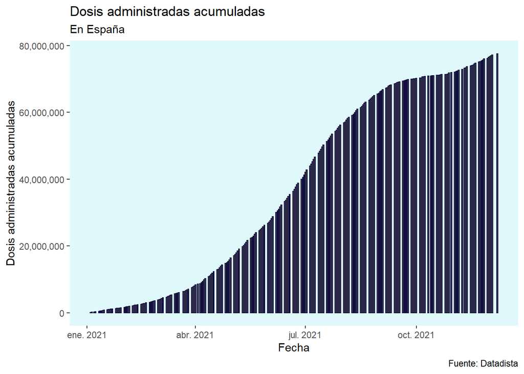

```r
ggplot(esp_datosVacunacionGit, aes(x = fecha_publicacion, y = dosis_administradas)) + geom_col(color = "#130f40") + theme(panel.background = element_rect(fill = "#dff9fb", colour = NA), panel.grid.major = element_blank(), panel.grid.minor = element_blank()) + labs(title = "Dosis administradas acumuladas",
              subtitle = "En España",
              caption = "Fuente: Datadista",
              x = "Fecha", y = "Dosis administradas acumuladas") + scale_y_continuous(labels = scales::comma)
```

Para las gráficas del número de vacunas entregadas según la marca voy a utilizar un nuevo tipo de gráfica para la que hará falta un nuevo paquete, además de crear un nuevo tipo de datos que hasta el momento no había utilizado.

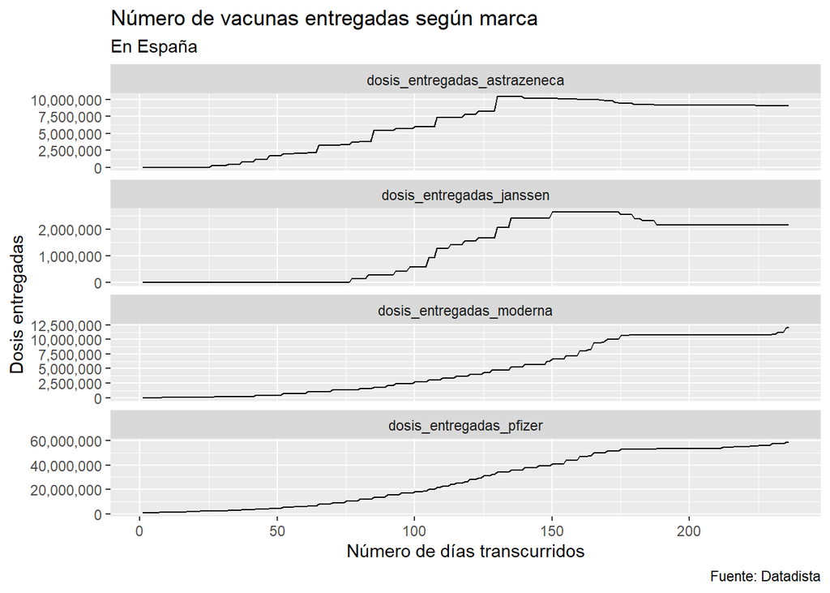

```r
# Después de instalar ggfortify.

library(ggfortify) # Ampliación de las funciones de ggplot2, incluyendo la función que nos hace falta: autoplot()

# Creamos un nuevo objeto basado en tiempo, esto es un cierto número de observaciones distribuidas a lo largo de un período de tiempo determinado y con una frecuencia definida. En este caso utilizaré un objeto ts para el que no será necesario instalar ningún otro paquete. Además puedo convertir mis variables del dataframe de vacunación a objetos ts con la función as.ts(), ya que están basadas en tiempo y son numéricas.

ts_esp_datosVacunacionGit <- as.ts(select(esp_datosVacunacionGit, dosis_entregadas_astrazeneca, dosis_entregadas_janssen, dosis_entregadas_moderna, dosis_entregadas_pfizer)) #En el objeto ts solamente estarán las variables de dosis entregadas según la marca.
autoplot(ts_esp_datosVacunacionGit) + labs(title = "Número de vacunas entregadas según marca",
              subtitle = "En España",
              caption = "Fuente: Datadista",
              x = "Número de días transcurridos", y = "Dosis entregadas") + scale_y_continuous(labels = scales::comma)
```

**Observaciones sobre la gráfica:** Se aprecia como las entregas más constantes y numerosas han sido las de Pfizer, seguidas de las de Moderna, AstraZeneca y Janssen.

Para la gráfica de evolución de la vacunación **diaria** en España vamos a necesitar dos paquetes nuevos. El primer paquete nos permitirá crear una gráfica interactiva que permite modificar el rango de selección de datos del eje x (en este caso el perídodo de tiempo). El segundo paquete nos permitirá crear un nuevo tipo de objeto basado en observaciones a lo largo del tiempo llamado **xts**. En esta ocasión no utilizamos un objeto ts por recomendación de la documentación de *dygraphs*, donde recomiendan utilizar objetos xts.

```r
# Después de instalar dygraphs y xts

library(dygraphs) # Introduce la librería de dygraphs para Javascript en R, permitiendo crear gráficas interactivas a partir de objetos xts.
library(xts) # Permite crear objetos xts.
xts_esp_datosVacunacionGit <- xts(x = esp_datosVacunacionGit$dosis_administradas_diarias, order.by = esp_datosVacunacionGit$fecha_publicacion)


dygraph(xts_esp_datosVacunacionGit, main = "Evolución diaria de la vacunación en España") %>% dyRangeSelector()
```

[interactive chart not shown]

```r
# En la siguiente gráfica se puede hacer hover sobre los datos para conocer el número de vacunados diarios en un momento determinado. Se puede ajustar el rango de fechas que toma el eje x moviendo los extremos de la barra que hay bajo la gráfica.
```

Para terminar el apartado de vacunación, he decidido hacer una gráfica interactiva en la que se compara el número de enfermos por covid con la curva de vacunación. El objetivo es crear una variable del porcentaje de enfermos por 100 000 habitantes en España y otra variable del porcentaje de la población vacunada en España. Una vez creadas, las comparo en una misma gráfica en la que la fecha se encuentra en el eje x.

El primer problema a resolver para poder lograr hacer la gráfica es la escasa concordancia entre las fechas de los dataframes de vacunación y del número de casos. Las fechas en las que se registran los datos difieren en cada uno de estos dataframes. Para encontrar las fechas en común en ambos dataframes y unir estos datos vamos a necesitar instalar un nuevo paquete llamado **fuzzyjoin**. Gracias a este paquete podremos encontrar las coincidencias entre los datos de cada dataframe y luego unirlos en uno nuevo.

```r
# Después de instalar fuzzyjoin

library(fuzzyjoin)

esp_vacunacionVScasos <- data.frame("fecha" = esp_casos_hosp_uci$fecha, "num_casos" = esp_casos_hosp_uci$num_casos) # Creamos el nuevo dataframe que contiene los datos de enfermos acumulados y la columna de fechas de ese dataframe.

esp_vacunacionVScasos <- esp_vacunacionVScasos %>%
  stringdist_inner_join(esp_datosVacunacionGit, by = c("fecha" = "fecha_publicacion"), max_dist = 0, distance_col = "distance")
# Al establecer max_dist = 0 solo las coincidencias exactas con la fecha se han copiado. Además he incluido la columna "distance" para poder detectar errores en el caso de que los hubiera, ya que el valor de esta variable siempre debe ser 0 en este caso.

esp_vacunacionVScasos$censo_esp <- c(47394223) #Introducimos el censo de España

esp_vacunacionVScasos <- esp_vacunacionVScasos %>% mutate(enfermos_diarios_por_100khab = (num_casos*100000) / censo_esp, porcentaje_vacunados = (personas_con_pauta_completa/censo_esp)*100) # Creamos las variables que vamos a utilizar en la gráfica mediante operaciones con otras variables.
```

Ahora que ya tenemos el dataframe y las variables que nos hacen falta vamos a crear el gráfico interactivo. Esta vez voy a utilizar el paquete **plotly**. Para hacer un gráfico interactivo con **plotly** se pueden seguir distintos pasos. En este caso he convertido mis gráficas de *ggplot2* a gráficas interactivas de **plotly**.

```r
# Tras haber instalado plotly

library(plotly) # Plotly utiliza la librería plotly.js de Javascript para crear los gráficos interactivos. Ofrece muchas posibilidades, como la creación de animaciones o controles personalizados, por eso es una muy buena opción para las aplicaciones con Shiny.

plotly_esp_vacunacionVScasos <- ggplot(esp_vacunacionVScasos, aes(x = fecha, y = enfermos_diarios_por_100khab)) + geom_line() + geom_line(aes(y = porcentaje_vacunados), color = "red", linetype = "solid") + labs(title = "% de vacunados en comparación con el nº de enfermos por 100 000 habitantes",
              subtitle = "",
              caption = "Fuente: Ministerio de sanidad y Datadista",
              x = "Fecha", y="") # Creamos la gráfica en ggplot2
plotly_esp_vacunacionVScasos <- ggplotly(plotly_esp_vacunacionVScasos) %>% layout(hovermode = 'x') # La pasamos a gráfica de plotly y establecemos la opción de comparar los datos en la y por defecto.
plotly_esp_vacunacionVScasos
```

[interactive chart not shown]

```r
#Los gráficos de plotly permiten hacer zoom en cualquier parte del gráfico para observar las tendencias con más detenimiento. Al hacer hover aparece la leyenda. Además, se puede descargar el gráfico en png después de modificarlo haciendo clic en el botón de la cámara en la barra de herramientas de la esquina superior derecha.
```

Comparación del número de enfermos por grupos de edad en distintas fechas (en la izquierda desde que la curva de vacunación va por primera vez por encima de la curva de enfermos por 100 000 habitantes, en la derecha desde que la curva de vacunación alcanza el 74% aproximadamente.) Es necesario instalar el paquete **ggpubr** para combinar las gráficas en un grid.

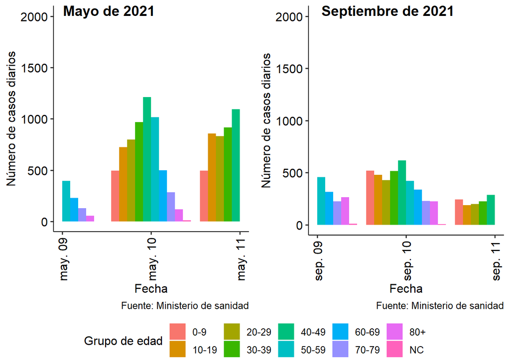

```r
# Tras instalar ggpubr

library(ggpubr) # Permite distribuir y anotar los gráficos de ggplot2 a la hora de introducirlos en un informe.

theme_set(theme_pubr()) # Establecemos los ajustes de ggpubr para optimice los gráficos pensando en publicarlos en un informe.

gedad_esp_casos_hosp_uci <- casos_hosp_uci %>% group_by(fecha, grupo_edad) %>% summarize(num_casos = sum(num_casos))
gedad_esp_casos_hosp_uci <- gedad_esp_casos_hosp_uci %>% select(fecha, grupo_edad, num_casos)


plot_gedad_esp_casos_hosp_uci_a <- ggplot(data = gedad_esp_casos_hosp_uci) +
geom_col(mapping = aes(x= fecha, y =  num_casos, fill = grupo_edad), position = "dodge") + scale_x_date(limits = as.Date(c("2021-05-09","2021-05-11"))) + ylim(0, 2000)+ theme(axis.text.x = element_text(angle = 90, vjust = 0.5, hjust=1)) + labs(fill = "Grupo de edad", caption = "Fuente: Ministerio de sanidad", x = "Fecha", y = "Número de casos diarios")

plot_gedad_esp_casos_hosp_uci_b <- ggplot(data = gedad_esp_casos_hosp_uci) +
  geom_col(mapping = aes(x= fecha, y = num_casos, fill = grupo_edad), position = "dodge") + scale_x_date(limits = as.Date(c("2021-09-09","2021-09-11"))) + ylim(0, 2000)+ theme(axis.text.x = element_text(angle = 90, vjust = 0.5, hjust=1)) + labs(fill = "Grupo de edad", caption = "Fuente: Ministerio de sanidad", x = "Fecha", y = "Número de casos diarios")

plot_gedad_esp_casos_hosp_uci_combined <- ggarrange(plot_gedad_esp_casos_hosp_uci_a, plot_gedad_esp_casos_hosp_uci_b, labels = c("   Mayo de 2021", "Septiembre de 2021"), ncol = 2, nrow = 1, common.legend = TRUE, legend = "bottom")
plot_gedad_esp_casos_hosp_uci_combined
```

### 4. Datos de mortalidad general en España

Ahora vamos a estudiar los datos de mortalidad en España. Para ello es necesario importar un nuevo dataframe.

```r
momo_iscii <- read_csv("https://momo.isciii.es/public/momo/data", col_names = TRUE) # Usamos el paquete readr

gedad_esp_momo_iscii <- filter(momo_iscii, ambito == "nacional", nombre_sexo == "todos") # Filtramos para conseguir los datos de España, dejando el grupo de edad para la primera gráfica

# Ahora filtramos de nuevo el dataframe para obtener los datos para todos los grupos de edad (segunda gráfica).
esp_momo_iscii <- filter(momo_iscii, ambito == "nacional", nombre_sexo == "todos", nombre_gedad == "todos")

#Utilizaremos las variables fecha_defuncion (fecha de defunción) y defunciones_observadas (defunciones en el día en cuestión)
```

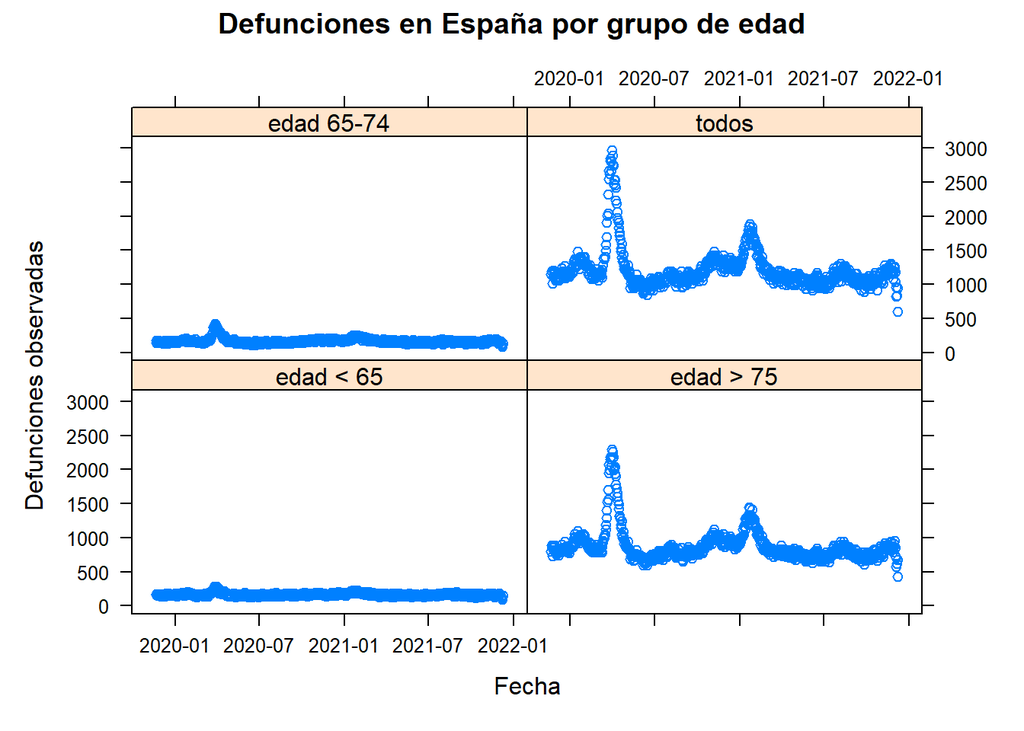

```r
#  Tras instalar lattice

library(lattice) # Se basa en una versión mejorada de las gráficas por defecto de R, pero destaca por la simplicidad a la hora de crear gráficas multivariable. También permite crear gráficas "trellis" que representan una variable o relación entre varias (estando esta representación condicionada a su vez por una o más variables).

xyplot(defunciones_observadas ~ fecha_defuncion | nombre_gedad, data = gedad_esp_momo_iscii, main="Defunciones en España por grupo de edad", ylab = "Defunciones observadas", xlab="Fecha")
```

Para comparar los fallecidos en 2021 con los de 2020 voy a crear un grid en el que estarán ambas gráficas. Usaré el paquete **ggpubr** para conseguir esto.

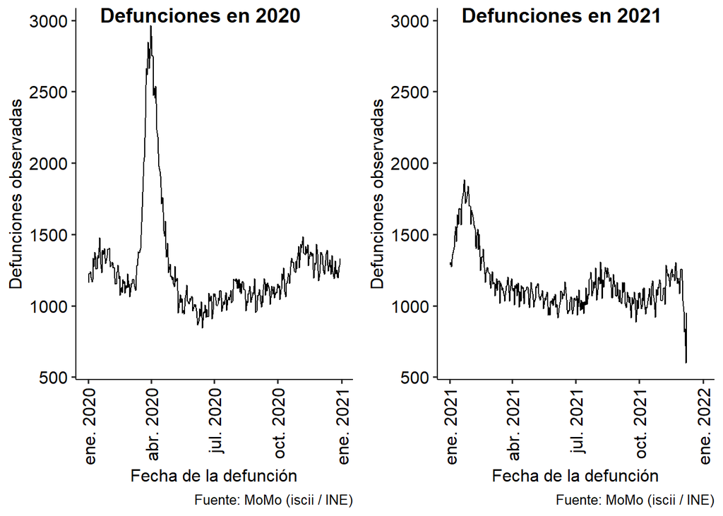

```r
# Ya habíamos utilizado ggpubr antes

library(ggpubr)

theme_set(theme_pubr())

plot_esp_momo_iscii_a <- ggplot(esp_momo_iscii, aes(x = fecha_defuncion, y = defunciones_observadas)) + geom_line() + scale_x_date(limits = as.Date(c("2020-01-01","2020-12-30")))+ theme(axis.text.x = element_text(angle = 90, vjust = 0.5, hjust=1)) + labs(caption = "Fuente: MoMo (iscii / INE)", x = "Fecha de la defunción", y = "Defunciones observadas")
plot_esp_momo_iscii_b <- ggplot(esp_momo_iscii, aes(x = fecha_defuncion, y = defunciones_observadas)) + geom_line() + scale_x_date(limits = as.Date(c("2021-01-01","2021-12-30")))+ theme(axis.text.x = element_text(angle = 90, vjust = 0.5, hjust=1)) + labs(caption = "Fuente: MoMo (iscii / INE)", x = "Fecha de la defunción", y = "Defunciones observadas")

plot_esp_momo_iscii_combined <- ggarrange(plot_esp_momo_iscii_a, plot_esp_momo_iscii_b, labels = c("Defunciones en 2020", "Defunciones en 2021"), ncol = 2, nrow = 1)  #Juntamos las dos gráficas que hemos creado en una sola

plot_esp_momo_iscii_combined
```

**Observaciones sobre la gráfica:** Se aprecia como el existe un aumento evidente en el número de defunciones alrededor de la fecha del primer confinamiento en España.

## Estudio de la pandemia en Extremadura

Para estudiar la pandemia en cada comunidad autónoma voy a reutilizar mi código, ya que mantendré el nombre de las variables al filtrar los datos para comunidad desde los dataframe iniciales. Los nombres de los dataframes contendran “extremadura” o “ex” en lugar de “esp”.

Filtramos los datos.

```r
extremadura_casos_diag_ccaa <- filter(casos_diag_ccaa, ccaa_iso == "EX")
extremadura_casos_hosp_uci <- bind_rows(filter(casos_hosp_uci,provincia_iso == "CC"), filter(casos_hosp_uci,provincia_iso == "BA"))
extremadura_casos_hosp_uci <- select(extremadura_casos_hosp_uci, -sexo, -grupo_edad, -provincia_iso)


# Si convertimos la variable $fecha en este último dataframe usando as.Date nos problemas, por eso lo pasaremos al formato fecha de lubridate, un paquete que está pensado para que transformar y operar con fechas sea más sencillo. Al ser lubridate del tidyverse podemos utilizarlo con mutate() de dyplr para convertir la columna de fecha a formato fecha sin complicaciones.

library(lubridate) # Al haber instalado tidyverse lubridate debería estar instalado, aunque al hacer library(tidyverse) no se carga.

extremadura_casos_hosp_uci <- extremadura_casos_hosp_uci %>%
  mutate(fecha = date(fecha)) %>%
  group_by(fecha) %>%
  summarize(num_casos = sum(num_casos), num_hosp = sum(num_hosp), num_uci = sum(num_uci), num_def = sum(num_def))
```

### 1. Evolución diaria de la pandemia en Extremadura

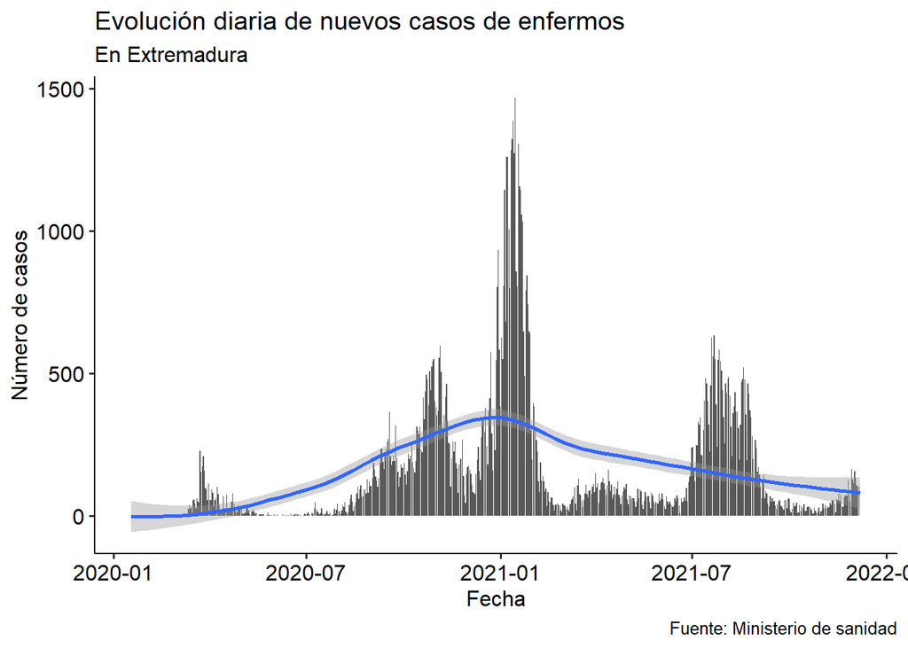

```r
# Utilizamos las variables $fecha (fecha en la que se registra la información) y $num_casos (número de casos nuevos) del dataframe extremadura_casos_diag_ccaa que contiene solamente los datos diarios correspondientes a Extremadura

ggplot(extremadura_casos_diag_ccaa, aes(x = fecha, y = num_casos)) + geom_col() + labs(title = "Evolución diaria de nuevos casos de enfermos",
              subtitle = "En Extremadura",
              caption = "Fuente: Ministerio de sanidad",
              x = "Fecha", y = "Número de casos") + geom_smooth()
```

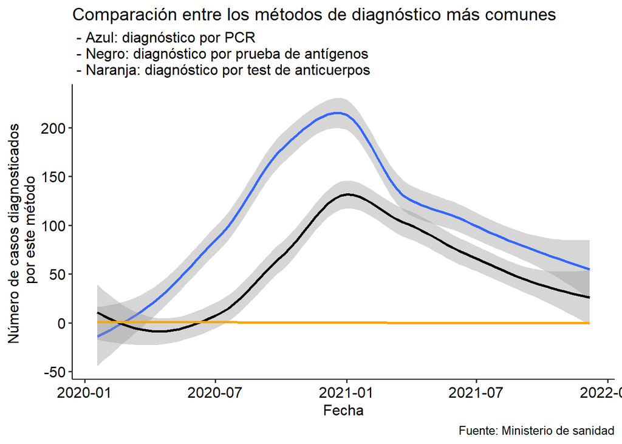

```r
# Utilizamos el mismo dataframe. Tres variables son de nueva introducción: $num_casos_prueba_pcr (número de casos con prueba de laboratorio PCR o técnicas moleculares), $num_casos_prueba_ag (número de casos con prueba de laboratorio de test de detección de antígeno) y $num_casos_prueba_test_ac (Número de casos con prueba de laboratorio de test rápido de anticuerpos).

ggplot(extremadura_casos_diag_ccaa, aes(x = fecha, y  = num_casos_prueba_pcr)) + geom_smooth() + geom_smooth(aes(y = num_casos_prueba_ag), color = "black") + geom_smooth(aes(y = num_casos_prueba_test_ac), color = "orange")  + labs(title = "Comparación entre los métodos de diagnóstico más comunes",
              subtitle = " - Azul: diagnóstico por PCR \n - Negro: diagnóstico por prueba de antígenos \n - Naranja: diagnóstico por test de anticuerpos",
              caption = "Fuente: Ministerio de sanidad",
              x = "Fecha", y = "Número de casos diagnosticados \n por este método")
```

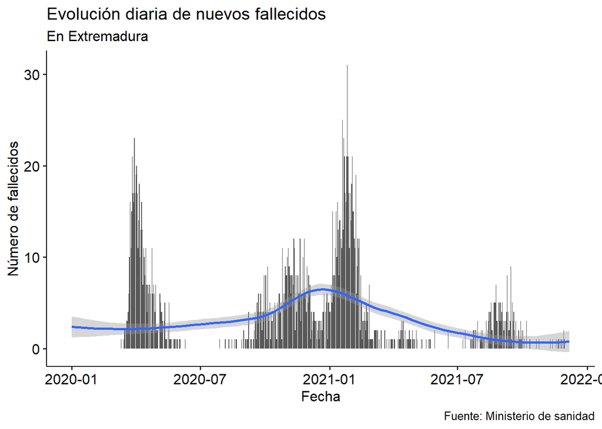

```r
#Utilizamos las variables $fecha (fecha en la que se registra la información) y $num_def (número de defunciones por COVID-19) del dataframe extremadura_casos_hosp_uci que contiene solamente los datos diarios correspondientes a Extremadura.

ggplot(extremadura_casos_hosp_uci, aes(x = fecha, y = num_def)) + geom_col() + labs(title = "Evolución diaria de nuevos fallecidos",
              subtitle = "En Extremadura",
              caption = "Fuente: Ministerio de sanidad",
              x = "Fecha", y = "Número de fallecidos") + geom_smooth()
```

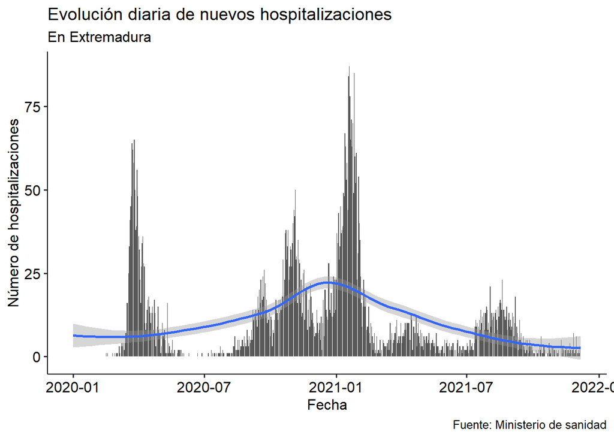

```r
#Utilizamos el dataframe anterior. Introducimos una nueva variable: $num_hosp (número de hospitalizados por COVID-19 diarios)

ggplot(extremadura_casos_hosp_uci, aes(x = fecha, y = num_hosp)) + geom_col() + labs(title = "Evolución diaria de nuevos hospitalizaciones",
              subtitle = "En Extremadura",
              caption = "Fuente: Ministerio de sanidad",
              x = "Fecha", y = "Número de hospitalizaciones") + geom_smooth()
```

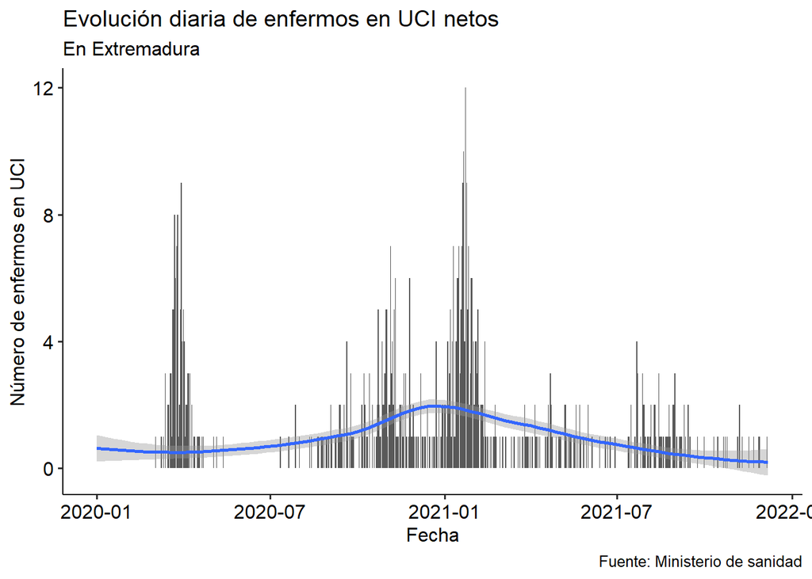

```r
#Utilizamos el dataframe anterior. Introducimos una nueva variable: $num_uci (número de enfermos en UCI por COVID-19 diarios)

ggplot(extremadura_casos_hosp_uci, aes(x = fecha, y = num_uci)) + geom_col() + labs(title = "Evolución diaria de enfermos en UCI netos",
              subtitle = "En Extremadura",
              caption = "Fuente: Ministerio de sanidad",
              x = "Fecha", y = "Número de enfermos en UCI") + geom_smooth()
```

```r
extremadura_casos_diag_ccaa$censo_extremadura <- c(1057999) #Introducimos en una variable el censo de Extremadura
extremadura_casos_diag_ccaa$ev100k_num_casos <- (extremadura_casos_diag_ccaa$num_casos * 100000) / extremadura_casos_diag_ccaa$censo_extremadura #Calculamos el número de casos por 100 000 habitantes
```

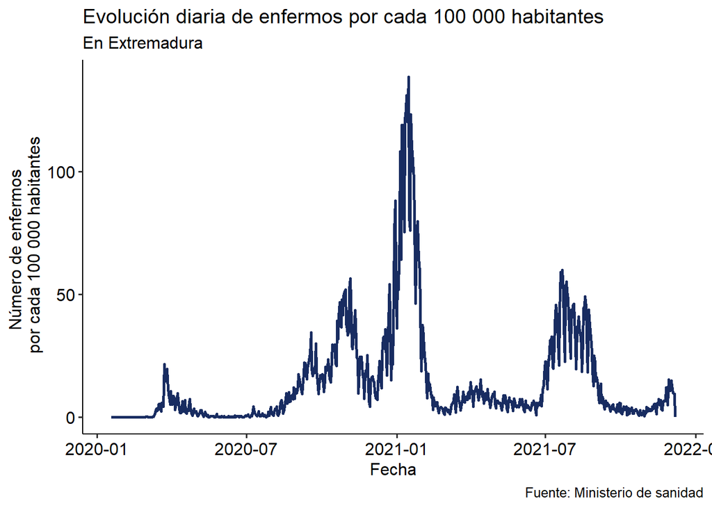

```r
ggplot(extremadura_casos_diag_ccaa, aes(x = fecha, y = ev100k_num_casos)) + geom_line(size = 1, color = "#182C61") + labs(title = "Evolución diaria de enfermos por cada 100 000 habitantes",
              subtitle = "En Extremadura",
              caption = "Fuente: Ministerio de sanidad",
              x = "Fecha", y = "Número de enfermos \n por cada 100 000 habitantes")
```

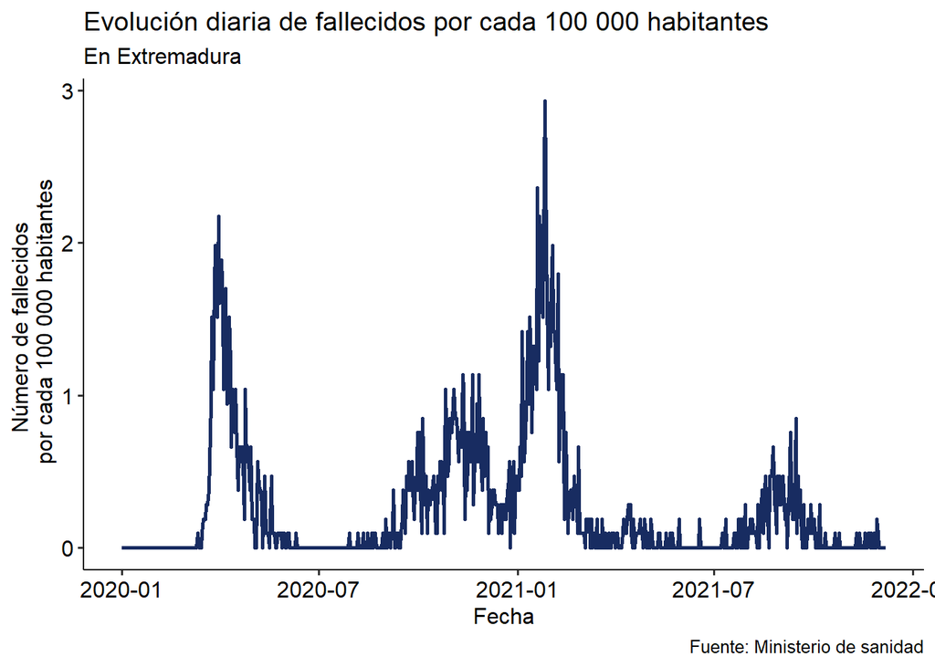

```r
extremadura_casos_hosp_uci$censo_extremadura <- c(1057999) #Introducimos en una variable el censo de Extremadura
extremadura_casos_hosp_uci$ev100k_num_def <- (extremadura_casos_hosp_uci$num_def * 100000) / extremadura_casos_hosp_uci$censo_extremadura #Calculamos el número de fallecidos por 100 000 habitantes


ggplot(extremadura_casos_hosp_uci, aes(x = fecha, y = ev100k_num_def)) + geom_line(size = 1, color = "#182C61") + labs(title = "Evolución diaria de fallecidos por cada 100 000 habitantes",
              subtitle = "En Extremadura",
              caption = "Fuente: Ministerio de sanidad",
              x = "Fecha", y = "Número de fallecidos \n por cada 100 000 habitantes")
```

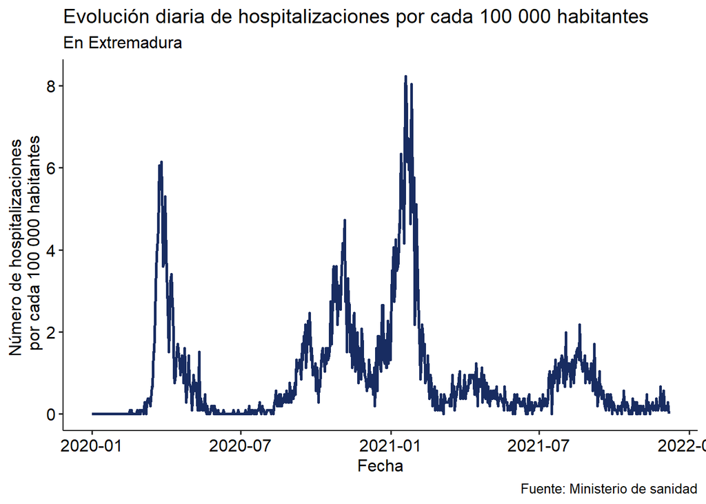

```r
extremadura_casos_hosp_uci$ev100k_num_hosp <- (extremadura_casos_hosp_uci$num_hosp * 100000) / extremadura_casos_hosp_uci$censo_extremadura #Calculamos el número de hospitalizados por 100 000 habitantes


ggplot(extremadura_casos_hosp_uci, aes(x = fecha, y = ev100k_num_hosp)) + geom_line(size = 1, color = "#182C61") + labs(title = "Evolución diaria de hospitalizaciones por cada 100 000 habitantes",
              subtitle = "En Extremadura",
              caption = "Fuente: Ministerio de sanidad",
              x = "Fecha", y = "Número de hospitalizaciones \n por cada 100 000 habitantes")
```